# MQuinho de inverno - R para análise de dados (script)

Rômulo Damasceno

6/7/2021

## 1.Onde estamos?

### 1.1. O R

O R é uma linguagem de programação desenvolvida por estatísticos, para finalidades estatísticas. Trata-se de uma linguagem extremamente eficiente na execução de procedimentos de análise de dados.

### 1.2. O RStudio

O RStudio é uma IDE (integrated development environment), que torna o ambiente de trabalho muito mais intuitivo, oferecendo novas interfaces e a possibilidade de visualização direta dos seus arquivos, objetos, gráficos, etc.

### 1.3. O RMarkdown

O RMarkdown é um dos tipos de arquivo mais importantes do R. Trata-se de um arquivo que permite a criação de um relatório e simultâneamente a execução de códigos de programação.

## 2. O processo de análise de dados

1. Importar
2. Limpar
3. **Compreender:** Transformar <–> Visualizar <–> Modelar
4. Comunicar

## 3. A iniciativa Tidyverse

[figure not shown]

O Tidyverse é um conjunto de pacotes do R que possui ferramentas para basicamente todos os problemas de análise de dados que você provavelmente vai enfrentar ao longo da vida nos seus trabalhos quantitativos. Todos os pacotes do tidyverse funcionam de maneira extremamente integrada e utilizá-los faz com que o trabalho fique realmente muito mais fácil.

**dplyr e tidyr:**

São os pacotes responsáveis (especialmente o dplyr) pelos procedimentos de query, manipulação de bancos de dados, seleção de colunas, filtragens por condições, reordenamento do banco de dados por condições, criação de novas variáveis, produção de estatísticas síntese, etc. Muito do nosso trabalho é feito aqui!

A principal função do tidyr é alterar estruturalmente os dataframes resultantes das funções do dplyr, transformando colunas em linhas, linhas em colunas, unindo-as ou separando-as. São funções bastante úteis ao manipular o dado para criar tabelas ou fazer operações com dataframes.

**forcats:**

Trabalhando com variáveis de tipo factor. Utilizado principalmente para reordenar os níveis de uma variável categórica.

**purrr:**

Utilizado para replicar procedimentos feitos em um vetor, para múltiplos vetores. É um grande aliado para evitar a repetição de código e poupa muito tempo de trabalho.

**ggplot2:**

Um dos pacotes mais importantes do tidyverse, o ggplot é capaz de produzir gráficos altamente customizáveis e bastante profissionais. É uma das ferramentas mais competentes disponíveis e mais largamente utilizadas para a função atualmente.

**stringr:**

A principal função do stringr é facilitar o trabalho com variáveis textuais despadronizadas (a resposta de uma pergunta aberta de um questionário por exemplo). O stringr é capaz de reconhecer padrões textuais e executar diversos tipos de transformações com eles.

**haven, readxl e readr**

Os três pacotes são responsáveis pela importação dos dados de diversos formatos para o R. o Haven é utilizado para formatos SPSS, SAS e Stata, o readxl lê arquivos de tipo excel e o readr lê arquivos de tipo textual, com separadores como vírgulas, pontos, ponto e vírgula, etc.

**tibble:**

O pacote tibble transforma dataframes em um formato mais simplificados deles próprios. É o formato de dataframes do tidyverse.

## 4. Programação: Noções preliminares

### 4.1. A Lógica de objetos e funções no R

1. Objetos nada mais são do que um agregado de informações em um formato: dataframes, listas, funções, etc.
2. Os objetos carregados podem ser visualizados na aba environment.
3. Eles são resultados de operações de atribuição.

**Exemplos:**

```r
# Atribua a um objeto 'x' o valor 1
x <- 1
x
```

```
## [1] 1
```

```r
# Atribua a um objeto 'Y' o conjunto de números 1,2,3,4 e 5
y <- c(1,2,3,4,5)
y <- c(1:5)

# Some os valores contidos no objeto y, salvando-os num vetor 'z'
z <- sum(y)
z
```

```
## [1] 15
```

```r
# Testes lógicos
x == y
```

```
## [1]  TRUE FALSE FALSE FALSE FALSE
```

Note que os objetos tem origem tanto em atribuições diretas de valores, como no caso do primeiro e do segundo exemplo, mas também podem ser resultado de aplicação de uma função a um objeto pré-existente, como no terceiro exemplo. Este último uso é o mais frequente, pois diversas são as vezes que precisamos guardar informações que são resultado de operações feitas com funções.

### 4.2. Diretório de trabalho ou diretório padrão

O diretório padrão é o local onde os arquivos, sejam eles de input (bancos de dados por exemplo) ou de output (figuras prontas, tabelas, etc) são guardados. Ao criar um novo projeto, o R nos dá a orientação de criar ou escolher um diretório padrão pré-existente. Lá será o local onde o software buscará os arquivos que solicitarmos.

```r
getwd()
```

```
## [1] "C:/Users/romul/Desktop/r_analisededados_mquinhoinverno"
```

## 5. Carregando e instalando os pacotes necessários

```r
# install.packages("tidyverse")
# install.packages("DataExplorer")
# install.packages("scales")
# install.packages("readxl")
# install.packages("kableExtra")
# install.packages("skimr")

library(tidyverse)
library(DataExplorer)
library(scales)
library(readxl)
library(kableExtra)
library(skimr)
```

## 6. Importação

### 6.1 Leitura do banco de dados - readr e readxl (Colocar o readr)

```r
# Extensão .xlsx (readxl)
titanic <- read_excel('titanic.xlsx')
titanic_csv <- read_csv('titanic_csv.csv')
# Visualização do banco completo
View(titanic)

# Removendo objetos
rm(titanic_csv)
```

Existem muitas funções que fazem a leitura de diferentes formatos de dados. As mais comuns são o read_csv e read_excel, porém existem opções para arquivo de tipo STATA, SAS, SPSS, entre outros.

## 7. Explorando o banco de dados

### 7.1. Análise da estrutura do banco de dados

**R base:**

1. [str()](https://stat.ethz.ch/R-manual/R-patched/library/utils/html/str.html): Mostra várias informações sobre a estrutura do dado
2. [summary()](https://stat.ethz.ch/R-manual/R-devel/library/base/html/summary.html): Estatísticas descritivas simples sobre cada coluna do dado
3. [colnames()](https://stat.ethz.ch/R-manual/R-devel/library/base/html/colnames.html): Mostra o nome das variáveis do dado
4. [head()](https://stat.ethz.ch/R-manual/R-devel/library/utils/html/head.html): Mostra o conteúdo das seis (ou mais, você escolhe) primeiras linhas do dado
5. [tail()](https://stat.ethz.ch/R-manual/R-devel/library/utils/html/head.html): Mostra o conteúdo das seis últimas linhas do dado
6. [View()](https://stat.ethz.ch/R-manual/R-devel/library/utils/html/View.html): Mostra o dado em formato de planilha (não recomendável para bases muito grandes e para PC’s com menor capacidade de processamento)
7. [skim()](https://stat.ethz.ch/R-manual/R-devel/library/utils/html/View.html): Produz algumas estatísticas descritivas extremamente úteis de maneira muito rápida e simplificada

```r
# R base - Banco inteiro
str(titanic)
```

```
## tibble [891 x 12] (S3: tbl_df/tbl/data.frame)
##  $ PassengerId: num [1:891] 1 2 3 4 5 6 7 8 9 10 ...
##  $ Survived   : num [1:891] 0 1 1 1 0 0 0 0 1 1 ...
##  $ Pclass     : num [1:891] 3 1 3 1 3 3 1 3 3 2 ...
##  $ Name       : chr [1:891] "Braund, Mr. Owen Harris" "Cumings, Mrs. John Bradley (Florence Briggs Thayer)" "Heikkinen, Miss. Laina" "Futrelle, Mrs. Jacques Heath (Lily May Peel)" ...
##  $ Sex        : chr [1:891] "male" "female" "female" "female" ...
##  $ Age        : num [1:891] 22 38 26 35 35 NA 54 2 27 14 ...
##  $ SibSp      : num [1:891] 1 1 0 1 0 0 0 3 0 1 ...
##  $ Parch      : num [1:891] 0 0 0 0 0 0 0 1 2 0 ...
##  $ Ticket     : chr [1:891] "A/5 21171" "PC 17599" "STON/O2. 3101282" "113803" ...
##  $ Fare       : num [1:891] 7.25 71.28 7.92 53.1 8.05 ...
##  $ Cabin      : chr [1:891] NA "C85" NA "C123" ...
##  $ Embarked   : chr [1:891] "S" "C" "S" "S" ...
```

```r
summary(titanic)
```

```
##   PassengerId       Survived          Pclass          Name
##  Min.   :  1.0   Min.   :0.0000   Min.   :1.000   Length:891
##  1st Qu.:223.5   1st Qu.:0.0000   1st Qu.:2.000   Class :character
##  Median :446.0   Median :0.0000   Median :3.000   Mode  :character
##  Mean   :446.0   Mean   :0.3838   Mean   :2.309
##  3rd Qu.:668.5   3rd Qu.:1.0000   3rd Qu.:3.000
##  Max.   :891.0   Max.   :1.0000   Max.   :3.000
##
##      Sex                 Age            SibSp           Parch
##  Length:891         Min.   : 0.42   Min.   :0.000   Min.   :0.0000
##  Class :character   1st Qu.:20.12   1st Qu.:0.000   1st Qu.:0.0000
##  Mode  :character   Median :28.00   Median :0.000   Median :0.0000
##                     Mean   :29.70   Mean   :0.523   Mean   :0.3816
##                     3rd Qu.:38.00   3rd Qu.:1.000   3rd Qu.:0.0000
##                     Max.   :80.00   Max.   :8.000   Max.   :6.0000
##                     NA's   :177
##     Ticket               Fare           Cabin             Embarked
##  Length:891         Min.   :  0.00   Length:891         Length:891
##  Class :character   1st Qu.:  7.91   Class :character   Class :character
##  Mode  :character   Median : 14.45   Mode  :character   Mode  :character
##                     Mean   : 32.20
##                     3rd Qu.: 31.00
##                     Max.   :512.33
##
```

```r
colnames(titanic)
```

```
##  [1] "PassengerId" "Survived"    "Pclass"      "Name"        "Sex"
##  [6] "Age"         "SibSp"       "Parch"       "Ticket"      "Fare"
## [11] "Cabin"       "Embarked"
```

```r
head(titanic)
```

```
## # A tibble: 6 x 12
##   PassengerId Survived Pclass Name    Sex     Age SibSp Parch Ticket  Fare Cabin
##         <dbl>    <dbl>  <dbl> <chr>   <chr> <dbl> <dbl> <dbl> <chr>  <dbl> <chr>
## 1           1        0      3 Braund~ male     22     1     0 A/5 2~  7.25 <NA>
## 2           2        1      1 Cuming~ fema~    38     1     0 PC 17~ 71.3  C85
## 3           3        1      3 Heikki~ fema~    26     0     0 STON/~  7.92 <NA>
## 4           4        1      1 Futrel~ fema~    35     1     0 113803 53.1  C123
## 5           5        0      3 Allen,~ male     35     0     0 373450  8.05 <NA>
## 6           6        0      3 Moran,~ male     NA     0     0 330877  8.46 <NA>
## # ... with 1 more variable: Embarked <chr>
```

```r
tail(titanic)
```

```
## # A tibble: 6 x 12
##   PassengerId Survived Pclass Name    Sex     Age SibSp Parch Ticket  Fare Cabin
##         <dbl>    <dbl>  <dbl> <chr>   <chr> <dbl> <dbl> <dbl> <chr>  <dbl> <chr>
## 1         886        0      3 "Rice,~ fema~    39     0     5 382652 29.1  <NA>
## 2         887        0      2 "Montv~ male     27     0     0 211536 13    <NA>
## 3         888        1      1 "Graha~ fema~    19     0     0 112053 30    B42
## 4         889        0      3 "Johns~ fema~    NA     1     2 W./C.~ 23.4  <NA>
## 5         890        1      1 "Behr,~ male     26     0     0 111369 30    C148
## 6         891        0      3 "Doole~ male     32     0     0 370376  7.75 <NA>
## # ... with 1 more variable: Embarked <chr>
```

```r
skim(titanic)
```

Data summary

| Name | titanic |
| --- | --- |
| Number of rows | 891 |
| Number of columns | 12 |
| _______________________ |  |
| Column type frequency: |  |
| character | 5 |
| numeric | 7 |
| ________________________ |  |
| Group variables | None |

**Variable type: character**

| skim_variable | n_missing | complete_rate | min | max | empty | n_unique | whitespace |
| --- | --- | --- | --- | --- | --- | --- | --- |
| Name | 0 | 1.00 | 12 | 82 | 0 | 891 | 0 |
| Sex | 0 | 1.00 | 4 | 6 | 0 | 2 | 0 |
| Ticket | 0 | 1.00 | 3 | 18 | 0 | 681 | 0 |
| Cabin | 687 | 0.23 | 1 | 15 | 0 | 147 | 0 |
| Embarked | 2 | 1.00 | 1 | 1 | 0 | 3 | 0 |

**Variable type: numeric**

| skim_variable | n_missing | complete_rate | mean | sd | p0 | p25 | p50 | p75 | p100 | hist |
| --- | --- | --- | --- | --- | --- | --- | --- | --- | --- | --- |
| PassengerId | 0 | 1.0 | 446.00 | 257.35 | 1.00 | 223.50 | 446.00 | 668.5 | 891.00 | ▇▇▇▇▇ |
| Survived | 0 | 1.0 | 0.38 | 0.49 | 0.00 | 0.00 | 0.00 | 1.0 | 1.00 | ▇▁▁▁▅ |
| Pclass | 0 | 1.0 | 2.31 | 0.84 | 1.00 | 2.00 | 3.00 | 3.0 | 3.00 | ▃▁▃▁▇ |
| Age | 177 | 0.8 | 29.70 | 14.53 | 0.42 | 20.12 | 28.00 | 38.0 | 80.00 | ▂▇▅▂▁ |
| SibSp | 0 | 1.0 | 0.52 | 1.10 | 0.00 | 0.00 | 0.00 | 1.0 | 8.00 | ▇▁▁▁▁ |
| Parch | 0 | 1.0 | 0.38 | 0.81 | 0.00 | 0.00 | 0.00 | 0.0 | 6.00 | ▇▁▁▁▁ |
| Fare | 0 | 1.0 | 32.20 | 49.69 | 0.00 | 7.91 | 14.45 | 31.0 | 512.33 | ▇▁▁▁▁ |

```r
# Coluna a coluna
summary(titanic$Sex)
```

```
##    Length     Class      Mode
##       891 character character
```

```r
head(titanic$Name)
```

```
## [1] "Braund, Mr. Owen Harris"
## [2] "Cumings, Mrs. John Bradley (Florence Briggs Thayer)"
## [3] "Heikkinen, Miss. Laina"
## [4] "Futrelle, Mrs. Jacques Heath (Lily May Peel)"
## [5] "Allen, Mr. William Henry"
## [6] "Moran, Mr. James"
```

```r
tail(titanic$Survived)
```

```
## [1] 0 0 1 0 1 0
```

### 7.2 Tipos de dado e conversões no R:

Existe uma infinidade de tipos de dados no R. Os mais importantes pra nós são:

1. **Characters/Strings -** Variáveis de texto reconhecidas como “sem padrão”.
2. **Numerics/Integers -** Numéricas em geral ou números inteiros
3. **Factors -** Variáveis textuais bastante específicas e com níveis, reconhecidas como tendo um padrão.

**NOTA:** Realizar operações com dados no formato errado é uma das fontes mais comuns de erros de diversos tipos.

#### 7.2.1. Conversão de dados no R

```r
# Jeito mais longo, mas mais intuitivo
titanic <- titanic %>%
  mutate(Survived = as.factor(Survived),
         Pclass = as.factor(Pclass),
         Sex = as.factor(Sex),
         Embarked = as.factor(Embarked))

# Criando um vetor com os nomes das variáveis que serão transformadas
cols2factor <- c('Survived', 'Pclass', 'Sex', 'Embarked')

# Transformando-as
titanic <- titanic %>%
  mutate_at(cols2factor, factor)
```

### 7.3 Utilizando o pacote DataExplorer

O DataExplorer é um pacote extremamente útil, pois faz essa parte de análise exploratória com um clique. As funcionalidades mais interessantes são a matriz de correlações, os gráficos para variáveis categóricas e as informações sobre a estrutura do dado.

#### 7.3.1 - Relatório descritivo completo

```r
 # titanic %>%
 #   create_report(
 #     output_file = 'titanic_report',
 #     report_title = 'EDA titanic'
 #   )
```

#### 7.3.2 - Pedaços específicos do relatório

```r
# Características gerais do banco de dados
titanic %>%
  introduce()
```

```
## # A tibble: 1 x 9
##    rows columns discrete_columns continuous_columns all_missing_columns
##   <int>   <int>            <int>              <int>               <int>
## 1   891      12                7                  5                   0
## # ... with 4 more variables: total_missing_values <int>, complete_rows <int>,
## #   total_observations <int>, memory_usage <dbl>
```

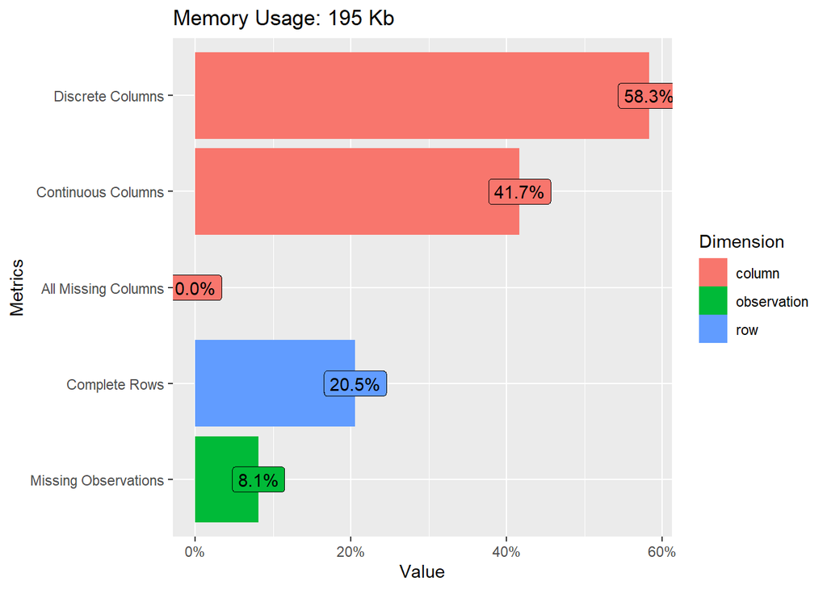

```r
# Número de colunas discretas, contínuas, missings
titanic %>%
  plot_intro()
```

```
## 3 columns ignored with more than 50 categories.
## Name: 891 categories
## Ticket: 681 categories
## Cabin: 148 categories
```

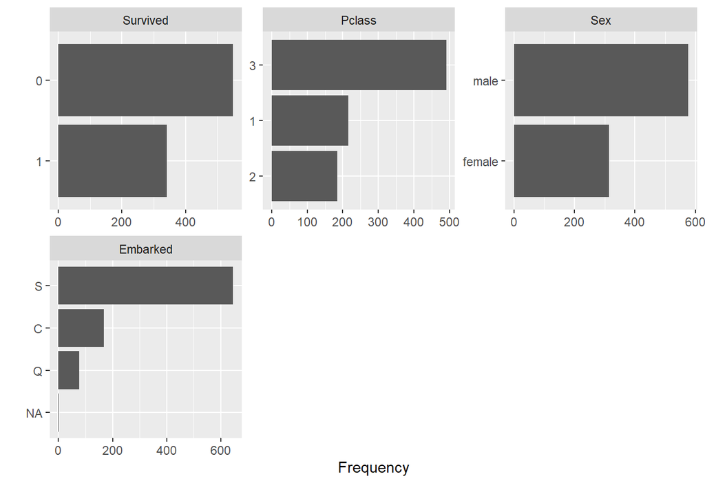

```r
#Gráficos de frequência das variáveis categóricas
titanic %>%
  plot_bar()
```

```
## 3 features with more than 20 categories ignored!
## Name: 891 categories
## Ticket: 681 categories
## Cabin: 148 categories
```

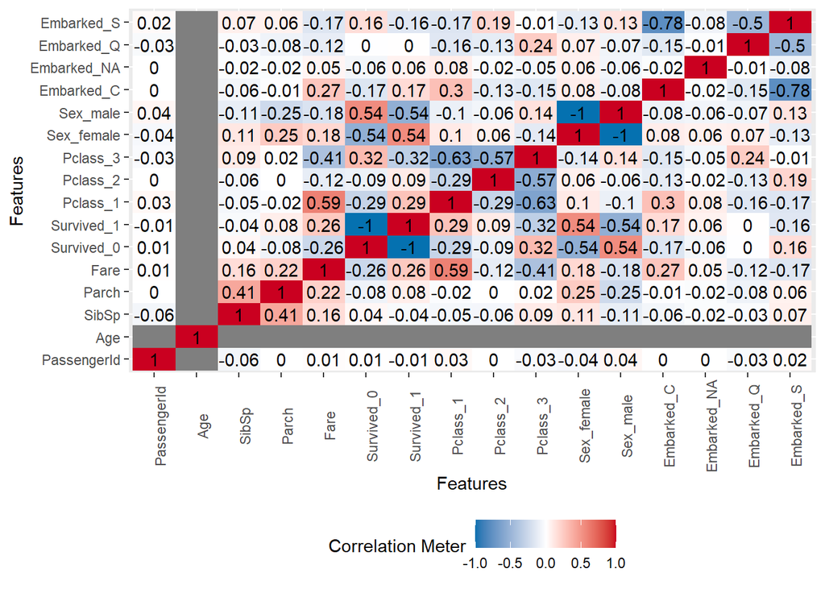

```r
#Gráfico de correlações
titanic %>%
  plot_correlation()
```

## 8. Manipulação do banco de dados utilizando o pacote dplyr (Data Wrangling)

O dplyr é um dos pacotes mais utilizados do tidyverse pois condensa várias funções que precisam ser utilizadas constantemente no processo de análise de dados, como seleção de colunas, filtragem de casos, recodificações de variáveis em outras, etc. Tais operações são feitas com 5 verbos principais:

- `filter()` : Filtra as observações por uma ou várias condições.
- `arrange()` : Reordena as linhas com base numa coluna de referência.
- `select()` : Seleciona as colunas desejadas.
- `mutate()` : Cria novas variáveis que são funções de variáveis pré-existentes.
- `summarise()` : Collapse many values down to a single summary.

### 8.1. Operadores lógicos auxiliares

Para diversos procedimentos no dplyr, são úteis os operadores lógicos:

Operadores lógicos no R

| Símbolo | Nome do operador | Exemplo |
| --- | --- | --- |
| > | Maior que | x > y |
| >= | Maior ou igual | x >= y |
| < | Menor que | x < y |
| <= | Menor ou igual | x <= y |
| == | Igual a | x == y |
| != | Diferente de | x != y |
| %in% e c() | Elementos específicos do conjunto | x %in% c(x,y,z) |
| \| | ou | x \| y |
| & | E | x & y |

### 8.2 Os verbos do dplyr:

#### 8.1.2. select()

É o verbo que permite a seleção de colunas/variáveis específicas do banco de dados.

```r
# Colunas especificadas
titanic %>%
  select(PassengerId, Name, Survived)
```

```
## # A tibble: 891 x 3
##    PassengerId Name                                                Survived
##          <dbl> <chr>                                               <fct>
##  1           1 Braund, Mr. Owen Harris                             0
##  2           2 Cumings, Mrs. John Bradley (Florence Briggs Thayer) 1
##  3           3 Heikkinen, Miss. Laina                              1
##  4           4 Futrelle, Mrs. Jacques Heath (Lily May Peel)        1
##  5           5 Allen, Mr. William Henry                            0
##  6           6 Moran, Mr. James                                    0
##  7           7 McCarthy, Mr. Timothy J                             0
##  8           8 Palsson, Master. Gosta Leonard                      0
##  9           9 Johnson, Mrs. Oscar W (Elisabeth Vilhelmina Berg)   1
## 10          10 Nasser, Mrs. Nicholas (Adele Achem)                 1
## # ... with 881 more rows
```

```r
# Todas menos uma específica
titanic %>%
  select(-PassengerId)
```

```
## # A tibble: 891 x 11
##    Survived Pclass Name      Sex     Age SibSp Parch Ticket  Fare Cabin Embarked
##    <fct>    <fct>  <chr>     <fct> <dbl> <dbl> <dbl> <chr>  <dbl> <chr> <fct>
##  1 0        3      Braund, ~ male     22     1     0 A/5 2~  7.25 <NA>  S
##  2 1        1      Cumings,~ fema~    38     1     0 PC 17~ 71.3  C85   C
##  3 1        3      Heikkine~ fema~    26     0     0 STON/~  7.92 <NA>  S
##  4 1        1      Futrelle~ fema~    35     1     0 113803 53.1  C123  S
##  5 0        3      Allen, M~ male     35     0     0 373450  8.05 <NA>  S
##  6 0        3      Moran, M~ male     NA     0     0 330877  8.46 <NA>  Q
##  7 0        1      McCarthy~ male     54     0     0 17463  51.9  E46   S
##  8 0        3      Palsson,~ male      2     3     1 349909 21.1  <NA>  S
##  9 1        3      Johnson,~ fema~    27     0     2 347742 11.1  <NA>  S
## 10 1        2      Nasser, ~ fema~    14     1     0 237736 30.1  <NA>  C
## # ... with 881 more rows
```

```r
# Várias exceto um conjunto específico
titanic %>%
  select(-c(PassengerId, Name, Survived))
```

```
## # A tibble: 891 x 9
##    Pclass Sex      Age SibSp Parch Ticket            Fare Cabin Embarked
##    <fct>  <fct>  <dbl> <dbl> <dbl> <chr>            <dbl> <chr> <fct>
##  1 3      male      22     1     0 A/5 21171         7.25 <NA>  S
##  2 1      female    38     1     0 PC 17599         71.3  C85   C
##  3 3      female    26     0     0 STON/O2. 3101282  7.92 <NA>  S
##  4 1      female    35     1     0 113803           53.1  C123  S
##  5 3      male      35     0     0 373450            8.05 <NA>  S
##  6 3      male      NA     0     0 330877            8.46 <NA>  Q
##  7 1      male      54     0     0 17463            51.9  E46   S
##  8 3      male       2     3     1 349909           21.1  <NA>  S
##  9 3      female    27     0     2 347742           11.1  <NA>  S
## 10 2      female    14     1     0 237736           30.1  <NA>  C
## # ... with 881 more rows
```

#### 8.1.3. filter()

É o verbo que permite a filtragem de linhas/casos do banco de dados por uma ou mais condições.

**Variáveis categóricas:**

```r
# Uma característica categórica
titanic %>%
  filter(Sex == 'female')
```

```
## # A tibble: 314 x 12
##    PassengerId Survived Pclass Name   Sex     Age SibSp Parch Ticket  Fare Cabin
##          <dbl> <fct>    <fct>  <chr>  <fct> <dbl> <dbl> <dbl> <chr>  <dbl> <chr>
##  1           2 1        1      Cumin~ fema~    38     1     0 PC 17~ 71.3  C85
##  2           3 1        3      Heikk~ fema~    26     0     0 STON/~  7.92 <NA>
##  3           4 1        1      Futre~ fema~    35     1     0 113803 53.1  C123
##  4           9 1        3      Johns~ fema~    27     0     2 347742 11.1  <NA>
##  5          10 1        2      Nasse~ fema~    14     1     0 237736 30.1  <NA>
##  6          11 1        3      Sands~ fema~     4     1     1 PP 95~ 16.7  G6
##  7          12 1        1      Bonne~ fema~    58     0     0 113783 26.6  C103
##  8          15 0        3      Vestr~ fema~    14     0     0 350406  7.85 <NA>
##  9          16 1        2      Hewle~ fema~    55     0     0 248706 16    <NA>
## 10          19 0        3      Vande~ fema~    31     1     0 345763 18    <NA>
## # ... with 304 more rows, and 1 more variable: Embarked <fct>
```

```r
# Duas características categóricas simultâneamente
titanic %>%
  filter(Sex == 'female' & Survived == '1')
```

```
## # A tibble: 233 x 12
##    PassengerId Survived Pclass Name   Sex     Age SibSp Parch Ticket  Fare Cabin
##          <dbl> <fct>    <fct>  <chr>  <fct> <dbl> <dbl> <dbl> <chr>  <dbl> <chr>
##  1           2 1        1      "Cumi~ fema~    38     1     0 PC 17~ 71.3  C85
##  2           3 1        3      "Heik~ fema~    26     0     0 STON/~  7.92 <NA>
##  3           4 1        1      "Futr~ fema~    35     1     0 113803 53.1  C123
##  4           9 1        3      "John~ fema~    27     0     2 347742 11.1  <NA>
##  5          10 1        2      "Nass~ fema~    14     1     0 237736 30.1  <NA>
##  6          11 1        3      "Sand~ fema~     4     1     1 PP 95~ 16.7  G6
##  7          12 1        1      "Bonn~ fema~    58     0     0 113783 26.6  C103
##  8          16 1        2      "Hewl~ fema~    55     0     0 248706 16    <NA>
##  9          20 1        3      "Mass~ fema~    NA     0     0 2649    7.22 <NA>
## 10          23 1        3      "McGo~ fema~    15     0     0 330923  8.03 <NA>
## # ... with 223 more rows, and 1 more variable: Embarked <fct>
```

```r
# Por uma característica ou outra
titanic %>%
  filter(Sex == 'female'| Embarked == 'S')
```

```
## # A tibble: 755 x 12
##    PassengerId Survived Pclass Name   Sex     Age SibSp Parch Ticket  Fare Cabin
##          <dbl> <fct>    <fct>  <chr>  <fct> <dbl> <dbl> <dbl> <chr>  <dbl> <chr>
##  1           1 0        3      Braun~ male     22     1     0 A/5 2~  7.25 <NA>
##  2           2 1        1      Cumin~ fema~    38     1     0 PC 17~ 71.3  C85
##  3           3 1        3      Heikk~ fema~    26     0     0 STON/~  7.92 <NA>
##  4           4 1        1      Futre~ fema~    35     1     0 113803 53.1  C123
##  5           5 0        3      Allen~ male     35     0     0 373450  8.05 <NA>
##  6           7 0        1      McCar~ male     54     0     0 17463  51.9  E46
##  7           8 0        3      Palss~ male      2     3     1 349909 21.1  <NA>
##  8           9 1        3      Johns~ fema~    27     0     2 347742 11.1  <NA>
##  9          10 1        2      Nasse~ fema~    14     1     0 237736 30.1  <NA>
## 10          11 1        3      Sands~ fema~     4     1     1 PP 95~ 16.7  G6
## # ... with 745 more rows, and 1 more variable: Embarked <fct>
```

```r
# Por um conjunto de características em uma mesma coluna
titanic %>%
  filter(Embarked %in% c('S','C'))
```

```
## # A tibble: 812 x 12
##    PassengerId Survived Pclass Name   Sex     Age SibSp Parch Ticket  Fare Cabin
##          <dbl> <fct>    <fct>  <chr>  <fct> <dbl> <dbl> <dbl> <chr>  <dbl> <chr>
##  1           1 0        3      Braun~ male     22     1     0 A/5 2~  7.25 <NA>
##  2           2 1        1      Cumin~ fema~    38     1     0 PC 17~ 71.3  C85
##  3           3 1        3      Heikk~ fema~    26     0     0 STON/~  7.92 <NA>
##  4           4 1        1      Futre~ fema~    35     1     0 113803 53.1  C123
##  5           5 0        3      Allen~ male     35     0     0 373450  8.05 <NA>
##  6           7 0        1      McCar~ male     54     0     0 17463  51.9  E46
##  7           8 0        3      Palss~ male      2     3     1 349909 21.1  <NA>
##  8           9 1        3      Johns~ fema~    27     0     2 347742 11.1  <NA>
##  9          10 1        2      Nasse~ fema~    14     1     0 237736 30.1  <NA>
## 10          11 1        3      Sands~ fema~     4     1     1 PP 95~ 16.7  G6
## # ... with 802 more rows, and 1 more variable: Embarked <fct>
```

**Variáveis numéricas:**

```r
# ----------- Filtragem por variáveis numéricas  ----------

# Um valor específico
titanic %>%
  filter(Age == 22)
```

```
## # A tibble: 27 x 12
##    PassengerId Survived Pclass Name   Sex     Age SibSp Parch Ticket  Fare Cabin
##          <dbl> <fct>    <fct>  <chr>  <fct> <dbl> <dbl> <dbl> <chr>  <dbl> <chr>
##  1           1 0        3      Braun~ male     22     1     0 A/5 2~  7.25 <NA>
##  2          61 0        3      Siray~ male     22     0     0 2669    7.23 <NA>
##  3          81 0        3      Waele~ male     22     0     0 345767  9    <NA>
##  4         113 0        3      Barto~ male     22     0     0 324669  8.05 <NA>
##  5         142 1        3      Nyste~ fema~    22     0     0 347081  7.75 <NA>
##  6         152 1        1      Pears~ fema~    22     1     0 113776 66.6  C2
##  7         213 0        3      Perki~ male     22     0     0 A/5 2~  7.25 <NA>
##  8         226 0        3      Bergl~ male     22     0     0 PP 43~  9.35 <NA>
##  9         244 0        3      Maenp~ male     22     0     0 STON/~  7.12 <NA>
## 10         288 0        3      Naide~ male     22     0     0 349206  7.90 <NA>
## # ... with 17 more rows, and 1 more variable: Embarked <fct>
```

```r
# Valores maiores ou iguais a / Menores ou iguais a
titanic %>%
  filter(Age >= 25)
```

```
## # A tibble: 436 x 12
##    PassengerId Survived Pclass Name   Sex     Age SibSp Parch Ticket  Fare Cabin
##          <dbl> <fct>    <fct>  <chr>  <fct> <dbl> <dbl> <dbl> <chr>  <dbl> <chr>
##  1           2 1        1      Cumin~ fema~    38     1     0 PC 17~ 71.3  C85
##  2           3 1        3      Heikk~ fema~    26     0     0 STON/~  7.92 <NA>
##  3           4 1        1      Futre~ fema~    35     1     0 113803 53.1  C123
##  4           5 0        3      Allen~ male     35     0     0 373450  8.05 <NA>
##  5           7 0        1      McCar~ male     54     0     0 17463  51.9  E46
##  6           9 1        3      Johns~ fema~    27     0     2 347742 11.1  <NA>
##  7          12 1        1      Bonne~ fema~    58     0     0 113783 26.6  C103
##  8          14 0        3      Ander~ male     39     1     5 347082 31.3  <NA>
##  9          16 1        2      Hewle~ fema~    55     0     0 248706 16    <NA>
## 10          19 0        3      Vande~ fema~    31     1     0 345763 18    <NA>
## # ... with 426 more rows, and 1 more variable: Embarked <fct>
```

```r
titanic %>%
  filter(Age <= 25)
```

```
## # A tibble: 301 x 12
##    PassengerId Survived Pclass Name  Sex     Age SibSp Parch Ticket   Fare Cabin
##          <dbl> <fct>    <fct>  <chr> <fct> <dbl> <dbl> <dbl> <chr>   <dbl> <chr>
##  1           1 0        3      "Bra~ male     22     1     0 A/5 2~   7.25 <NA>
##  2           8 0        3      "Pal~ male      2     3     1 349909  21.1  <NA>
##  3          10 1        2      "Nas~ fema~    14     1     0 237736  30.1  <NA>
##  4          11 1        3      "San~ fema~     4     1     1 PP 95~  16.7  G6
##  5          13 0        3      "Sau~ male     20     0     0 A/5. ~   8.05 <NA>
##  6          15 0        3      "Ves~ fema~    14     0     0 350406   7.85 <NA>
##  7          17 0        3      "Ric~ male      2     4     1 382652  29.1  <NA>
##  8          23 1        3      "McG~ fema~    15     0     0 330923   8.03 <NA>
##  9          25 0        3      "Pal~ fema~     8     3     1 349909  21.1  <NA>
## 10          28 0        1      "For~ male     19     3     2 19950  263    C23 ~
## # ... with 291 more rows, and 1 more variable: Embarked <fct>
```

```r
# Valores num intervalo
titanic %>%
  filter(Age >= 22 & Age <= 25)
```

```
## # A tibble: 97 x 12
##    PassengerId Survived Pclass Name  Sex     Age SibSp Parch Ticket   Fare Cabin
##          <dbl> <fct>    <fct>  <chr> <fct> <dbl> <dbl> <dbl> <chr>   <dbl> <chr>
##  1           1 0        3      Brau~ male     22     1     0 A/5 2~   7.25 <NA>
##  2          61 0        3      Sira~ male     22     0     0 2669     7.23 <NA>
##  3          76 0        3      Moen~ male     25     0     0 348123   7.65 F G73
##  4          81 0        3      Wael~ male     22     0     0 345767   9    <NA>
##  5          89 1        1      Fort~ fema~    23     3     2 19950  263    C23 ~
##  6          90 0        3      Celo~ male     24     0     0 343275   8.05 <NA>
##  7          98 1        1      Gree~ male     23     0     1 PC 17~  63.4  D10 ~
##  8         113 0        3      Bart~ male     22     0     0 324669   8.05 <NA>
##  9         119 0        1      Baxt~ male     24     0     1 PC 17~ 248.   B58 ~
## 10         128 1        3      Mads~ male     24     0     0 C 173~   7.14 <NA>
## # ... with 87 more rows, and 1 more variable: Embarked <fct>
```

```r
titanic %>%
  filter(between(Age, 22, 25))
```

```
## # A tibble: 97 x 12
##    PassengerId Survived Pclass Name  Sex     Age SibSp Parch Ticket   Fare Cabin
##          <dbl> <fct>    <fct>  <chr> <fct> <dbl> <dbl> <dbl> <chr>   <dbl> <chr>
##  1           1 0        3      Brau~ male     22     1     0 A/5 2~   7.25 <NA>
##  2          61 0        3      Sira~ male     22     0     0 2669     7.23 <NA>
##  3          76 0        3      Moen~ male     25     0     0 348123   7.65 F G73
##  4          81 0        3      Wael~ male     22     0     0 345767   9    <NA>
##  5          89 1        1      Fort~ fema~    23     3     2 19950  263    C23 ~
##  6          90 0        3      Celo~ male     24     0     0 343275   8.05 <NA>
##  7          98 1        1      Gree~ male     23     0     1 PC 17~  63.4  D10 ~
##  8         113 0        3      Bart~ male     22     0     0 324669   8.05 <NA>
##  9         119 0        1      Baxt~ male     24     0     1 PC 17~ 248.   B58 ~
## 10         128 1        3      Mads~ male     24     0     0 C 173~   7.14 <NA>
## # ... with 87 more rows, and 1 more variable: Embarked <fct>
```

```r
# Um conjunto específico de valores
titanic %>%
  filter(Age %in% c(22, 23, 30, 35))
```

```
## # A tibble: 85 x 12
##    PassengerId Survived Pclass Name  Sex     Age SibSp Parch Ticket   Fare Cabin
##          <dbl> <fct>    <fct>  <chr> <fct> <dbl> <dbl> <dbl> <chr>   <dbl> <chr>
##  1           1 0        3      Brau~ male     22     1     0 A/5 2~   7.25 <NA>
##  2           4 1        1      Futr~ fema~    35     1     0 113803  53.1  C123
##  3           5 0        3      Alle~ male     35     0     0 373450   8.05 <NA>
##  4          21 0        2      Fynn~ male     35     0     0 239865  26    <NA>
##  5          61 0        3      Sira~ male     22     0     0 2669     7.23 <NA>
##  6          80 1        3      Dowd~ fema~    30     0     0 364516  12.5  <NA>
##  7          81 0        3      Wael~ male     22     0     0 345767   9    <NA>
##  8          89 1        1      Fort~ fema~    23     3     2 19950  263    C23 ~
##  9          98 1        1      Gree~ male     23     0     1 PC 17~  63.4  D10 ~
## 10         113 0        3      Bart~ male     22     0     0 324669   8.05 <NA>
## # ... with 75 more rows, and 1 more variable: Embarked <fct>
```

#### 8.1.4. mutate()

Cria novas variáveis ou altera as pré-existentes partindo das variáveis iniciais do banco de dados.

```r
# Número de familiares a bordo
titanic %>%
  mutate(n_familiares = SibSp + Parch)
```

```
## # A tibble: 891 x 13
##    PassengerId Survived Pclass Name   Sex     Age SibSp Parch Ticket  Fare Cabin
##          <dbl> <fct>    <fct>  <chr>  <fct> <dbl> <dbl> <dbl> <chr>  <dbl> <chr>
##  1           1 0        3      Braun~ male     22     1     0 A/5 2~  7.25 <NA>
##  2           2 1        1      Cumin~ fema~    38     1     0 PC 17~ 71.3  C85
##  3           3 1        3      Heikk~ fema~    26     0     0 STON/~  7.92 <NA>
##  4           4 1        1      Futre~ fema~    35     1     0 113803 53.1  C123
##  5           5 0        3      Allen~ male     35     0     0 373450  8.05 <NA>
##  6           6 0        3      Moran~ male     NA     0     0 330877  8.46 <NA>
##  7           7 0        1      McCar~ male     54     0     0 17463  51.9  E46
##  8           8 0        3      Palss~ male      2     3     1 349909 21.1  <NA>
##  9           9 1        3      Johns~ fema~    27     0     2 347742 11.1  <NA>
## 10          10 1        2      Nasse~ fema~    14     1     0 237736 30.1  <NA>
## # ... with 881 more rows, and 2 more variables: Embarked <fct>,
## #   n_familiares <dbl>
```

```r
# case_when(): Passageiros por faixa etária (Procedimento de recodificação)
titanic <- titanic %>%
  mutate(faixas_etarias = case_when(Age <= 15 ~ '15 anos ou menos',
                                    Age >= 16 & Age <= 29 ~ '16 a 29',
                                    Age >= 30 & Age <= 49 ~ '30 a 49',
                                    Age >= 50 & Age <= 59 ~ '50 a 59',
                                    Age >= 60 ~ '60 ou mais'))
## Forma 2
titanic <- titanic %>%
  mutate(faixas_etarias1 = case_when(Age <= 15 ~ '15 anos ou menos',
                                     between(Age, 16, 29) ~ '16 a 29',
                                     between(Age, 30, 49) ~ '30 a 49',
                                     between(Age, 50, 59) ~ '50 a 59',
                                     Age >= 60 ~ '60 ou mais'))

# if_else: Passageiro idoso dummy
titanic %>%
  mutate(idoso_dummy = if_else(condition = Age >= 60,
                               true = 1,
                               false = 0))
```

```
## # A tibble: 891 x 15
##    PassengerId Survived Pclass Name   Sex     Age SibSp Parch Ticket  Fare Cabin
##          <dbl> <fct>    <fct>  <chr>  <fct> <dbl> <dbl> <dbl> <chr>  <dbl> <chr>
##  1           1 0        3      Braun~ male     22     1     0 A/5 2~  7.25 <NA>
##  2           2 1        1      Cumin~ fema~    38     1     0 PC 17~ 71.3  C85
##  3           3 1        3      Heikk~ fema~    26     0     0 STON/~  7.92 <NA>
##  4           4 1        1      Futre~ fema~    35     1     0 113803 53.1  C123
##  5           5 0        3      Allen~ male     35     0     0 373450  8.05 <NA>
##  6           6 0        3      Moran~ male     NA     0     0 330877  8.46 <NA>
##  7           7 0        1      McCar~ male     54     0     0 17463  51.9  E46
##  8           8 0        3      Palss~ male      2     3     1 349909 21.1  <NA>
##  9           9 1        3      Johns~ fema~    27     0     2 347742 11.1  <NA>
## 10          10 1        2      Nasse~ fema~    14     1     0 237736 30.1  <NA>
## # ... with 881 more rows, and 4 more variables: Embarked <fct>,
## #   faixas_etarias <chr>, faixas_etarias1 <chr>, idoso_dummy <dbl>
```

#### 8.1.5. group_by() e summarise()

- `group_by()`: Agrupa as observações do banco de dados para as quais serão calculadas alguma estatística (Por exemplo: contagem de homens e mulheres por ter ou não sobrevivido ao acidente).
- `summarise()` : Computa estatísticas para agrupamentos prévios do banco de dados.

**Tabelas univariadas:**

```r
# Contagem de sobreviventes e não sobreviventes
titanic %>%
  group_by(Survived) %>%
  summarise(contagem = n())
```

```
## # A tibble: 2 x 2
##   Survived contagem
##   <fct>       <int>
## 1 0             549
## 2 1             342
```

```r
# Percentual de sobreviventes e não sobreviventes
titanic %>%
  group_by(Survived) %>%
  summarise(contagem = n()) %>%
  mutate(percentual = contagem/sum(contagem))
```

```
## # A tibble: 2 x 3
##   Survived contagem percentual
##   <fct>       <int>      <dbl>
## 1 0             549      0.616
## 2 1             342      0.384
```

**Tabelas bivariadas:**

```r
# Contagem de sobreviventes e não sobreviventes por sexo
titanic %>%
  group_by(Survived, Sex) %>%
  summarise(contagem = n())
```

```
## # A tibble: 4 x 3
## # Groups:   Survived [2]
##   Survived Sex    contagem
##   <fct>    <fct>     <int>
## 1 0        female       81
## 2 0        male        468
## 3 1        female      233
## 4 1        male        109
```

```r
# Percentual de sobreviventes e não sobreviventes por sexo
titanic %>%
  group_by(Survived, Sex) %>%
  summarise(contagem = n()) %>%
  mutate(percentual = contagem/sum(contagem))
```

```
## # A tibble: 4 x 4
## # Groups:   Survived [2]
##   Survived Sex    contagem percentual
##   <fct>    <fct>     <int>      <dbl>
## 1 0        female       81      0.148
## 2 0        male        468      0.852
## 3 1        female      233      0.681
## 4 1        male        109      0.319
```

```r
# Formato de tabela
sobreviventes_sexo <- titanic %>%
  group_by(Survived, Sex) %>%
  summarise(contagem = n()) %>%
  mutate(percentual = contagem/sum(contagem)) %>%
  select(-contagem) %>%
  pivot_wider(names_from = Sex,
              values_from = percentual)
sobreviventes_sexo
```

```
## # A tibble: 2 x 3
## # Groups:   Survived [2]
##   Survived female  male
##   <fct>     <dbl> <dbl>
## 1 0         0.148 0.852
## 2 1         0.681 0.319
```

**Computando estatísticas para grupos**

```r
# ---------------- Estatísticas básicas - Idade ----------------
titanic %>%
  group_by(Sex) %>%
  summarise(media_idade = mean(Age, na.rm = T),
            desvio_idade = sd(Age, na.rm = T),
            min = min(Age, na.rm = T),
            q25 = quantile(Age, probs = 0.25, na.rm = T),
            q50 = quantile(Age, probs = 0.5, na.rm = T),
            q75 = quantile(Age, probs = 0.75, na.rm = T),
            max = max(Age, na.rm = T),
            IQR = IQR(Age, na.rm = T))
```

```
## # A tibble: 2 x 9
##   Sex    media_idade desvio_idade   min   q25   q50   q75   max   IQR
##   <fct>        <dbl>        <dbl> <dbl> <dbl> <dbl> <dbl> <dbl> <dbl>
## 1 female        27.9         14.1  0.75    18    27    37    63    19
## 2 male          30.7         14.7  0.42    21    29    39    80    18
```

```r
# Para evitar a repetição de na.rm = T em todos os argumentos
titanic %>%
  filter(is.na(Age) == FALSE) %>%
  group_by(Sex) %>%
  summarise(media_idade = mean(Age),
            desvio_idade = sd(Age),
            min = min(Age),
            q25 = quantile(Age, probs = 0.25),
            q50 = quantile(Age, probs = 0.5),
            q75 = quantile(Age, probs = 0.75),
            max = max(Age),
            IQR = IQR(Age))
```

```
## # A tibble: 2 x 9
##   Sex    media_idade desvio_idade   min   q25   q50   q75   max   IQR
##   <fct>        <dbl>        <dbl> <dbl> <dbl> <dbl> <dbl> <dbl> <dbl>
## 1 female        27.9         14.1  0.75    18    27    37    63    19
## 2 male          30.7         14.7  0.42    21    29    39    80    18
```